# **AUTHOR** : CHINMAY ROZEKAR

# Project Python Foundations: FoodHub Data Analysis

### Context

The number of restaurants in New York is increasing day by day. Lots of students and busy professionals rely on those restaurants due to their hectic lifestyles. Online food delivery service is a great option for them. It provides them with good food from their favorite restaurants. A food aggregator company FoodHub offers access to multiple restaurants through a single smartphone app.

The app allows the restaurants to receive a direct online order from a customer. The app assigns a delivery person from the company to pick up the order after it is confirmed by the restaurant. The delivery person then uses the map to reach the restaurant and waits for the food package. Once the food package is handed over to the delivery person, he/she confirms the pick-up in the app and travels to the customer's location to deliver the food. The delivery person confirms the drop-off in the app after delivering the food package to the customer. The customer can rate the order in the app. The food aggregator earns money by collecting a fixed margin of the delivery order from the restaurants.

### Objective

The food aggregator company has stored the data of the different orders made by the registered customers in their online portal. They want to analyze the data to get a fair idea about the demand of different restaurants which will help them in enhancing their customer experience. Suppose you are hired as a Data Scientist in this company and the Data Science team has shared some of the key questions that need to be answered. Perform the data analysis to find answers to these questions that will help the company to improve the business.

### Data Description

The data contains the different data related to a food order. The detailed data dictionary is given below.

### Data Dictionary

- order_id: Unique ID of the order
- customer_id: ID of the customer who ordered the food
- restaurant_name: Name of the restaurant
- cuisine_type: Cuisine ordered by the customer
- cost_of_the_order: Cost of the order
- day_of_the_week: Indicates whether the order is placed on a weekday or weekend (The weekday is from Monday to Friday and the weekend is Saturday and Sunday)
- rating: Rating given by the customer out of 5
- food_preparation_time: Time (in minutes) taken by the restaurant to prepare the food. This is calculated by taking the difference between the timestamps of the restaurant's order confirmation and the delivery person's pick-up confirmation.
- delivery_time: Time (in minutes) taken by the delivery person to deliver the food package. This is calculated by taking the difference between the timestamps of the delivery person's pick-up confirmation and drop-off information

### Let us start by importing the required libraries

```python
# Installing the libraries with the specified version.
!pip install numpy==1.25.2 pandas==1.5.3 matplotlib==3.7.1 seaborn==0.13.1 -q --user
```

[output not shown]

**Note**: *After running the above cell, kindly restart the notebook kernel and run all cells sequentially from the start again.*

```python
# import libraries for data manipulation
import numpy as np
import pandas as pd

# import libraries for data visualization
import matplotlib.pyplot as plt
import seaborn as sns
```

### Understanding the structure of the data

```python
# uncomment and run the following lines for Google Colab
# from google.colab import drive
# drive.mount('/content/drive')
```

```python
from google.colab import drive
drive.mount('/content/drive')
```

```python
# Write your code here to read the data
data = pd.read_csv('/content/drive/MyDrive/PGP-AIML UT AUSTIN/foodhub_order.csv')
```

```python
# Write your code here to view the first 5 rows
data.head(5)
```

|  | order_id | customer_id | restaurant_name | cuisine_type | cost_of_the_order | day_of_the_week | rating | food_preparation_time | delivery_time |
| --- | --- | --- | --- | --- | --- | --- | --- | --- | --- |
| 0 | 1477147 | 337525 | Hangawi | Korean | 30.75 | Weekend | Not given | 25 | 20 |
| 1 | 1477685 | 358141 | Blue Ribbon Sushi Izakaya | Japanese | 12.08 | Weekend | Not given | 25 | 23 |
| 2 | 1477070 | 66393 | Cafe Habana | Mexican | 12.23 | Weekday | 5 | 23 | 28 |
| 3 | 1477334 | 106968 | Blue Ribbon Fried Chicken | American | 29.20 | Weekend | 3 | 25 | 15 |
| 4 | 1478249 | 76942 | Dirty Bird to Go | American | 11.59 | Weekday | 4 | 25 | 24 |

### **Question 1:** How many rows and columns are present in the data? [0.5 mark]

```python
# Write your code here
data.shape

print(f"Rows: {data.shape[0]}, Columns: {data.shape[1]}")
```

[output not shown]

#### Observations:

There are 1898 rows and 9 columns

### **Question 2:** What are the datatypes of the different columns in the dataset? (The info() function can be used) [0.5 mark]

```python
# Write your code here

# This can be implemented in various ways:

# Method 1:
data.info(verbose=True)   # cons: Very Messy display's everything

print("############################################################\n")
print("########## METHOD 2 : ##########")

# Method2 2:
data.dtypes # pros: clean tabular display
print(data.dtypes)

grouped_dtypes = data.dtypes.groupby(data.dtypes)
print("############################################################\n")
print(" -- COLUMNS BY DATATYPES----\n")
# Printing the results
for dtype, cols in grouped_dtypes:
    print(f"{dtype}: {list(cols.index)}")
```

```
<class 'pandas.core.frame.DataFrame'>
RangeIndex: 1898 entries, 0 to 1897
Data columns (total 9 columns):
 #   Column                 Non-Null Count  Dtype
---  ------                 --------------  -----
 0   order_id               1898 non-null   int64
 1   customer_id            1898 non-null   int64
 2   restaurant_name        1898 non-null   object
 3   cuisine_type           1898 non-null   object
 4   cost_of_the_order      1898 non-null   float64
 5   day_of_the_week        1898 non-null   object
 6   rating                 1898 non-null   object
 7   food_preparation_time  1898 non-null   int64
 8   delivery_time          1898 non-null   int64
dtypes: float64(1), int64(4), object(4)
memory usage: 133.6+ KB
############################################################

########## METHOD 2 : ##########
order_id                   int64
customer_id                int64
restaurant_name           object
cuisine_type              object
cost_of_the_order        float64
day_of_the_week           object
rating                    object
food_preparation_time      int64
delivery_time              int64
dtype: object
############################################################

 -- COLUMNS BY DATATYPES----

int64: ['order_id', 'customer_id', 'food_preparation_time', 'delivery_time']
float64: ['cost_of_the_order']
object: ['restaurant_name', 'cuisine_type', 'day_of_the_week', 'rating']
```

#### Observations:

1. There are total 5 numerical columns
- 1 column of type float, cost_of_the_order, Makes sense as prices can be float
- There are 4 columns of the type integers
2. There are 4 columns of type object, Why is rating an Object? should be numerical values or float values
3. day_of_the_week is should be more specific

### **Question 3:** Are there any missing values in the data? If yes, treat them using an appropriate method. [1 mark]

```python
# Write your code here

# first check, if any duplicate values
data.duplicated().sum()

# then check for null values
data.isnull().sum()

print(f"There are {data.duplicated().sum().sum()} duplicate values in this Dataset")

print(f"There are {data.isnull().sum().sum()} missing values in this Dataset")
```

```
There are 0 duplicate values in this Dataset
There are 0 missing values in this Dataset
```

#### Observations:

- There are 0 duplicate values in this Dataset
- There are 0 missing values in this Dataset

### **Question 4:** Check the statistical summary of the data. What is the minimum, average, and maximum time it takes for food to be prepared once an order is placed? [2 marks]

```python
# Write your code here
minTime = data['food_preparation_time'].min()

avgTime = data['food_preparation_time'].mean()

maxTime = data['food_preparation_time'].max()

print(f"Minimum time: {minTime} minutes")
print(f"Average time: {avgTime:.2f} minutes")  # 2 decimal places only
print(f"Maximum time: {maxTime} minutes")
```

```
Minimum time: 20 minutes
Average time: 27.37 minutes
Maximum time: 35 minutes
```

#### Observations:

- Minimum time: 20 minutes
- Average time: 27.37 minutes
- Maximum time: 35 minutes

### **Question 5:** How many orders are not rated? [1 mark]

```python
# Write the code here

# Method 1:
# not_rated_orders = (data['rating'] == "Not given").sum()
# print(f"Number of orders not rated: {not_rated_orders}")


# the above implementation is flawed, because you never know if one of the
# items is "NaN" or something like "###$$" could be anything

# -------------------------------------------------------------------
# Method 2:

# I know that "rating" col is an object meaning items can either be string or
# float or anything godknows

# So I need to know what are the unique items in this column and print this
# as a list:
j = data['rating'].unique()

print(f"unique items in ratings column: {j}\n")

for item in j:
  ratings = (data['rating'] == item).sum()
  print(f"The rating for {item}:= {ratings}")
```

```
unique items in ratings column: ['Not given' '5' '3' '4']

The rating for Not given:= 736
The rating for 5:= 588
The rating for 3:= 188
The rating for 4:= 386
```

#### Observations:

736 orders are not rated

### Exploratory Data Analysis (EDA)

### **Question 6:** Explore all the variables and provide observations on their distributions. (Generally, histograms, boxplots, countplots, etc. are used for univariate exploration.) [9 marks]

```python
# Write the code here


# step 1: I hate all the 'Not given' values in this column doesnt make sense to me, so I m converting it to Nan, also check for duplicate values

#load new Dataset
data_new = pd.read_csv('/content/drive/MyDrive/PGP-AIML UT AUSTIN/foodhub_order.csv',  na_values=["Not given"])
data_new.isnull().sum()


# print(data_new.dtypes)

print(f"There are {data_new.isnull().sum().sum()} 'Not given' values in ratings column, which are converted to NaN")
print(f"This means there are {data_new.isnull().sum().sum()} ratings which are missing")
print(f"There are {data_new.duplicated().sum().sum()} duplicate values in this Dataset")

# data_new
```

```
There are 736 'Not given' values in ratings column, which are converted to NaN
This means there are 736 ratings which are missing
There are 0 duplicate values in this Dataset
```

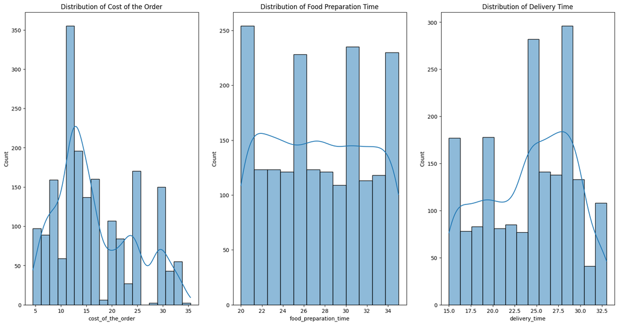

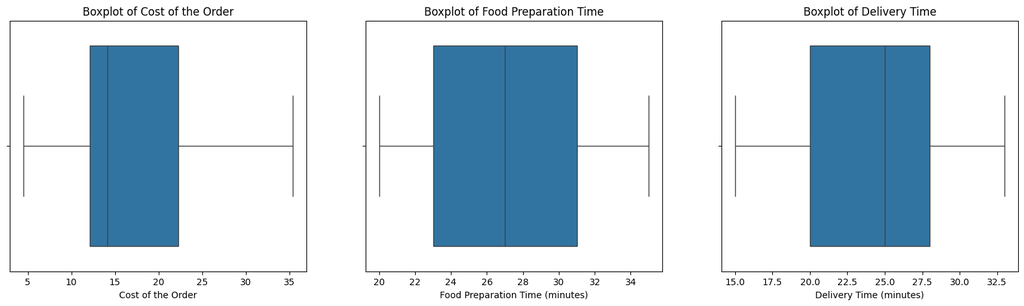

```python
# Plots in Univraiate Analysis:
# - Histogram
# - Boxplot
# - Bar Graph
# - Line plot


#-------------------------------------------------------------
# HISTOGRAM
plt.figure(figsize=(20, 10))
#Cost of the Order: Histogram with KDE
plt.subplot(1, 3, 1)
sns.histplot(data=data_new,x='cost_of_the_order',kde=True)
plt.title('Distribution of Cost of the Order')


#Food Preparation Time: Histogram with KDE
plt.subplot(1, 3, 2)
sns.histplot(data=data_new,x='food_preparation_time',kde=True)
plt.title('Distribution of Food Preparation Time')


#Delivery Time: Histogram with KDE
plt.subplot(1, 3, 3)
sns.histplot(data=data_new,x='delivery_time',kde=True)
plt.title('Distribution of Delivery Time')

#-------------------------------------------------------------
# BOXPLOT:

plt.figure(figsize=(20,5))
#Cost of the Order: Boxplot
plt.subplot(1, 3, 1)
sns.boxplot(data=data_new,x='cost_of_the_order')
plt.title('Boxplot of Cost of the Order')
plt.xlabel('Cost of the Order')

#Food Preparation Time: Boxplot
plt.subplot(1, 3, 2)
sns.boxplot(data=data_new,x='food_preparation_time')
plt.title('Boxplot of Food Preparation Time')
plt.xlabel('Food Preparation Time (minutes)')

#Delivery Time: Boxplot
plt.subplot(1, 3, 3)
sns.boxplot(data=data_new,x='delivery_time')
plt.title('Boxplot of Delivery Time')
plt.xlabel('Delivery Time (minutes)')
plt.show()
```

**Food Preparation Time**: Most dishes take a solid 20-30 minutes to whip up—nothing out of the ordinary. No wild variations here, just a steady rhythm, with the median prep time clocking in at about 27 minutes.

**Delivery Time:** Expect your food to hit your doorstep in about 20-30 minutes, give or take. The distribution tilts slightly left, meaning a few lucky ones get their food quicker. The median delivery time lands around 25 minutes.

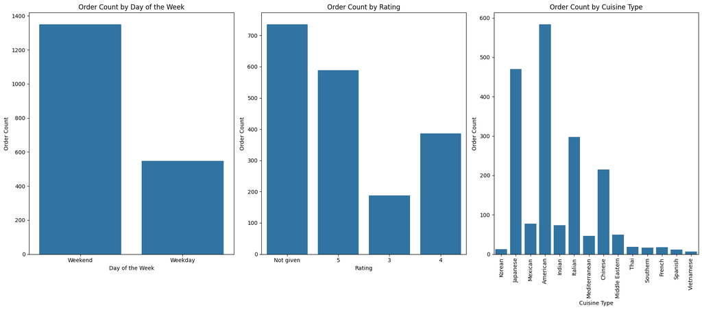

```python
plt.figure(figsize=(18,8))  # plotting area

# Day of the Week: Countplot
plt.subplot(1, 3, 1)
sns.countplot(data=data_new, x='day_of_the_week');
plt.title('Order Count by Day of the Week')
plt.xlabel('Day of the Week')
plt.ylabel('Order Count')

# Rating: Countplot
plt.subplot(1, 3, 2)
sns.countplot(data=data, x='rating');
# sns.countplot(data=data_new, x='rating');
plt.title('Order Count by Rating')
plt.xlabel('Rating')
plt.ylabel('Order Count')

# Cuisine Type: Countplot
plt.subplot(1, 3, 3)
sns.countplot(data=data_new, x='cuisine_type');
plt.title('Order Count by Cuisine Type')
plt.xlabel('Cuisine Type')
plt.ylabel('Order Count')
plt.xticks(rotation=90)
plt.tight_layout()
plt.show()
```

**Day of the Week:** Orders pick up noticeably over the weekend—no surprise there. People are taking a break from cooking and indulging a little more.

**Rating**: Many customers skip leaving a rating, but when they do, the feedback is generally positive. Seems like most people are happy with their orders!

**Cuisine Type**: While there’s a good mix of cuisines being ordered, American food remains the go-to favorite. Classic comfort food never goes out of style!

```
day_of_the_week
Weekday    16.311188
Weekend    16.574833
Name: cost_of_the_order, dtype: float64
```

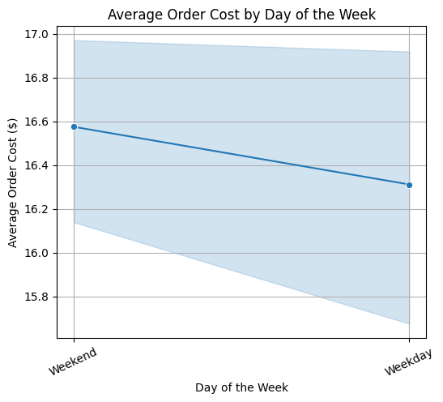

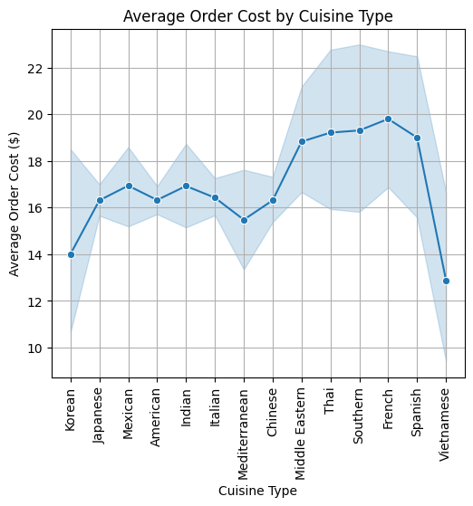

```python
# print(data_new.dtypes)

data_new

avg_cost_per_day = data_new.groupby("day_of_the_week")["cost_of_the_order"].mean()
day_order = ["Weekday", "Weekend"]
avg_cost_per_day = avg_cost_per_day.reindex(day_order)
print(avg_cost_per_day)


# Line plots
# Average Order Cost by Day of the Week
plt.figure(figsize=(20,5))
plt.subplot(1, 3, 1)
sns.lineplot(data=data_new, x="day_of_the_week", y="cost_of_the_order", estimator="mean", marker="o")

plt.xlabel("Day of the Week")
plt.ylabel("Average Order Cost ($)")
plt.title("Average Order Cost by Day of the Week")
plt.xticks(rotation=25)  # Rotate labels for better readability
plt.grid(True)


plt.show()

# Average Order Cost by Cuisine Type
# Creating the Seaborn line plot
plt.figure(figsize=(20,5))
plt.subplot(1, 3, 2)

sns.lineplot(data=data_new, x="cuisine_type", y="cost_of_the_order", estimator="mean", marker="o")

plt.xlabel("Cuisine Type")
plt.ylabel("Average Order Cost ($)")
plt.title("Average Order Cost by Cuisine Type")
plt.xticks(rotation=90)  # Rotate labels for better readability
plt.grid(True)
plt.show()
```

### Average Order Cost by Day of the Week

- Week day: ~$16.31
- Week end: ~$16.57

The average order cost is slightly higher on weekends, suggesting people might be indulging a bit more when they have time to relax.

- In terms of cost, Vietnamese food is the cheapest as compared to all cuisines, and French cuisine is the most expensive

### **Question 7**: Which are the top 5 restaurants in terms of the number of orders received? [1 mark]

```python
# Write the code here


top_restaurants = data_new['restaurant_name'].value_counts().sort_values(ascending=False)
top_restaurants
top_restaurants.head(5)
```

| restaurant_name | count |
| --- | --- |
| Shake Shack | 219 |
| The Meatball Shop | 132 |
| Blue Ribbon Sushi | 119 |
| Blue Ribbon Fried Chicken | 96 |
| Parm | 68 |

**dtype:** int64

### **Question 8**: Which is the most popular cuisine on weekends? [1 mark]

```
The most popular cuisine on weekends is American
```

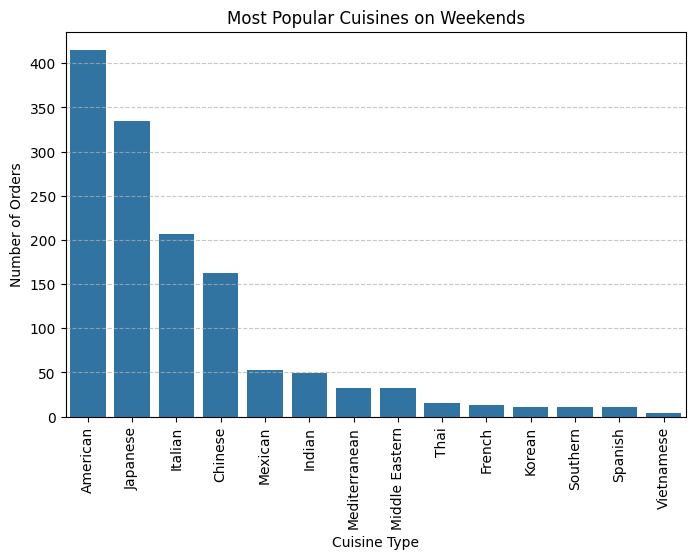

```python
# Write the code


weekend_data = data_new[data_new["day_of_the_week"] == "Weekend"]
popular_cuisine_weekend = weekend_data["cuisine_type"].value_counts().idxmax()

print(f"The most popular cuisine on weekends is {popular_cuisine_weekend}")

cuisine_counts_weekend = weekend_data["cuisine_type"].value_counts()


plt.figure(figsize=(8, 5))
sns.barplot(x=cuisine_counts_weekend.index, y=cuisine_counts_weekend.values)
plt.xlabel("Cuisine Type")
plt.ylabel("Number of Orders")
plt.title("Most Popular Cuisines on Weekends")
plt.xticks(rotation=90)
plt.grid(axis="y", linestyle="--", alpha=0.7)


plt.show()
```

#### Observations:

### **Question 9**: What percentage of the orders cost more than 20 dollars? [2 marks]

```python
# Write the code here

above_20_dollars = data_new[data_new['cost_of_the_order'] > 20]
total_orders = len(data_new)
above_20_percent = (len(above_20_dollars) / total_orders) * 100
print(f"The percentage of orders costing more than $20 is {above_20_percent:.2f}%")
```

```
The percentage of orders costing more than $20 is 29.24%
```

#### Observations:

The percentage of orders costing more than $20 is 29.24%

### **Question 10**: What is the mean order delivery time? [1 mark]

```python
# Write the code here
mean_delivery_time = data_new['delivery_time'].mean()
print(f"The mean order delivery time is {mean_delivery_time:.2f} minutes")
```

```
The mean order delivery time is 24.16 minutes
```

#### Observations:

The mean order delivery time is 24.16 minutes

### **Question 11:** The company has decided to give 20% discount vouchers to the top 3 most frequent customers. Find the IDs of these customers and the number of orders they placed. [1 mark]

```python
# Write the code here
top_customers = data_new['customer_id'].value_counts().nlargest(3)
# print(top_customers)

for customer_id, order_count in top_customers.items():
    print(f"Customer ID: {customer_id:<6} | Orders Placed: {order_count}")
```

```
Customer ID: 52832  | Orders Placed: 13
Customer ID: 47440  | Orders Placed: 10
Customer ID: 83287  | Orders Placed: 9
```

#### Observations:

The top 3 most frequent customers who will recieve 20% discount vouchers are:

Customer ID 52832 placed 13 orders

Customer ID 47440 placed 10 orders

Customer ID 83287 placed 9 orders

### **Question 12**: Perform a multivariate analysis to explore relationships between the important variables in the dataset. (It is a good idea to explore relations between numerical variables as well as relations between numerical and categorical variables) [10 marks]

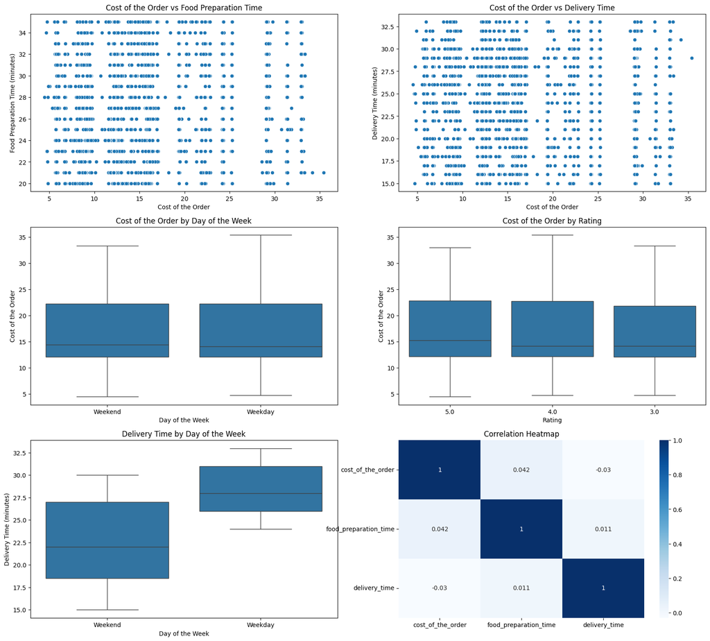

```python
# Write the code here

plt.figure(figsize=(20, 18))  # plotting area

# Relationship between Cost of the Order and Food Preparation Time
plt.subplot(3, 2, 1)
sns.scatterplot(data=data_new, x='cost_of_the_order', y='food_preparation_time')
plt.title('Cost of the Order vs Food Preparation Time')
plt.xlabel('Cost of the Order')
plt.ylabel('Food Preparation Time (minutes)')

# Relationship between Cost of the Order and Delivery Time
plt.subplot(3, 2, 2)
sns.scatterplot(data=data_new, x='cost_of_the_order', y='delivery_time')
plt.title('Cost of the Order vs Delivery Time')
plt.xlabel('Cost of the Order')
plt.ylabel('Delivery Time (minutes)')

# Boxplot of Cost by Day of the Week
plt.subplot(3, 2, 3)
sns.boxplot(data=data_new, x='day_of_the_week', y='cost_of_the_order')
plt.title('Cost of the Order by Day of the Week')
plt.xlabel('Day of the Week')
plt.ylabel('Cost of the Order')

# Boxplot of Cost by Rating
plt.subplot(3, 2, 4)
sns.boxplot(data=data_new, x='rating', y='cost_of_the_order', order=data_new['rating'].value_counts().index)
plt.title('Cost of the Order by Rating')
plt.xlabel('Rating')
plt.ylabel('Cost of the Order')

# Boxplot of Delivery Time by Day of the Week
plt.subplot(3, 2, 5)
sns.boxplot(data=data_new, x='day_of_the_week', y='delivery_time')
plt.title('Delivery Time by Day of the Week')
plt.xlabel('Day of the Week')
plt.ylabel('Delivery Time (minutes)')

# Heatmap of Correlations between Numerical Variables
plt.subplot(3, 2, 6)
sns.heatmap(data_new[['cost_of_the_order', 'food_preparation_time', 'delivery_time']].corr(), annot=True, cmap='Blues')
plt.title('Correlation Heatmap')
```

**Order Cost vs. Delivery Time**: Whether an order is pricey or cheap, delivery time remains consistent. The cost of the meal doesn’t influence how fast it reaches the customer.

**Order Cost by Day of the Week:** Spending habits remain steady throughout the week. There’s no significant variation in how much people spend on different days.

**Order Cost by Rating:** High ratings appear across all price ranges, showing that customer satisfaction isn’t just about cost. Both low-cost and high-cost meals receive positive reviews.

**Relationships Between Variables:** No strong connections exist between cost, preparation time, and delivery time. These factors operate independently without influencing each other significantly.

### **Question 13:** The company wants to provide a promotional offer in the advertisement of the restaurants. The condition to get the offer is that the restaurants must have a rating count of more than 50 and the average rating should be greater than 4. Find the restaurants fulfilling the criteria to get the promotional offer. [3 marks]

```python
# Write the code here
data_new['rating'].dropna()

restaurants = data_new.groupby('restaurant_name')['rating'].agg(['count', 'mean'])

restaurants_promo = restaurants[(restaurants['count'] > 50) & (restaurants['mean'] > 4)]

# print(restaurants_promo)

for i in restaurants_promo.index:
  print(i)
```

```
Blue Ribbon Fried Chicken
Blue Ribbon Sushi
Shake Shack
The Meatball Shop
```

#### Observations:

- only 4 restaurants quaalify for discounts
  - Blue Ribbon Fried Chicken
  - Blue Ribbon Sushi
  - Shake Shack
  - The Meatball Shop

### **Question 14:** The company charges the restaurant 25% on the orders having cost greater than 20 dollars and 15% on the orders having cost greater than 5 dollars. Find the net revenue generated by the company across all orders. [3 marks]

```python
# Write the code here

data_new
data_new['cost_of_the_order']

net_revenue = 0
for cost in data_new['cost_of_the_order']:
  if cost > 20:
    net_revenue += cost * 0.25
  elif cost > 5:
    net_revenue += cost * 0.15

print(f"The net revenue generated by the company across all orders is ${net_revenue:.2f}")
```

```
The net revenue generated by the company across all orders is $6166.30
```

#### Observations:

The net revenue generated by the company across all orders is $6166.30

### **Question 15:** The company wants to analyze the total time required to deliver the food. What percentage of orders take more than 60 minutes to get delivered from the time the order is placed? (The food has to be prepared and then delivered.) [2 marks]

```python
# Write the code here
data_new

data_new['total_time'] = data_new['food_preparation_time'] + data_new['delivery_time']
data_new['total_time']

print(len(data_new['total_time']))

# print(data_new['total_time'] > 60)

print((data_new['total_time'] > 60).sum())


precentage_gt_60 = (data_new['total_time'] > 60).sum() / len(data_new) * 100

print(f"{precentage_gt_60:.2f} % orders take more than 60 min")
```

```
1898
200
10.54 % orders take more than 60 min
```

#### Observations:

10.54 % orders take more than 60 min

### **Question 16:** The company wants to analyze the delivery time of the orders on weekdays and weekends. How does the mean delivery time vary during weekdays and weekends? [2 marks]

```python
# Write the code here

data_new.groupby('day_of_the_week')['delivery_time'].mean()

for day, time in data_new.groupby('day_of_the_week')['delivery_time'].mean().items():
  print(f"{day}: {time:.2f} min")
```

```
Weekday: 28.34 min
Weekend: 22.47 min
```

#### Observations:

Delivery times:

- Weekday: 28.34 min
- Weekend: 22.47 min

Delivery time on weekend is around 6 min faster. Perhaps due to less traffic.

### Conclusion and Recommendations

### **Question 17:** What are your conclusions from the analysis? What recommendations would you like to share to help improve the business? (You can use cuisine type and feedback ratings to drive your business recommendations.) [6 marks]

### Conclusions:

- **Top 5 Restaurants by Order Count:** Leading the charts is **Shake Shack** with 219 orders, followed by **The Meatball Shop, Blue Ribbon Sushi, Blue Ribbon Fried Chicken,** and **Parm**.
- **Most Popular Cuisine on Weekends:** **American cuisine** dominates weekend orders, showing a strong customer preference for classic comfort food.
- **Customer Ratings Insight:** **736 orders (39% of total) were not rated,** suggesting a significant number of customers skip providing feedback.
- **Restaurants Eligible for Promotions:** **Blue Ribbon Fried Chicken, Blue Ribbon Sushi, Shake Shack,** and **The Meatball Shop** qualify for promotional offers, each boasting **over 50 ratings with an average above 4**.
- **High-Value Orders & Revenue Impact:** **29.24% of orders exceeded $20,** drawing a **25% commission**, significantly contributing to total earnings.
- **Total Commission Earned:** The company generated **approximately $6,166 in commission**, with a major share coming from higher-cost orders.
- **Time Metrics:** The **average food preparation time is 27 minutes**, while **delivery averages 24 minutes**.
- **Weekend vs. Weekday Delivery:** **Weekend deliveries are faster (22.47 minutes) compared to 28.34 minutes on weekdays,** likely due to improved efficiency.
- **Top Customers & Loyalty Incentives:** The **top 3 most frequent customers** qualify for **special discounts**, encouraging repeat business and brand loyalty.

### Recommendations:

- Enhance Customer Engagement for Ratings
- Since 39% of orders were not rated, encourage feedback by offering small incentives (e.g., discounts on the next order, loyalty points).
- Send follow-up notifications or emails reminding customers to leave a rating.
- Leverage Popular Restaurants for Promotions
  - Feature Shake Shack, The Meatball Shop, and Blue Ribbon outlets in marketing campaigns to attract more customers.
  - Offer exclusive deals through high-rated restaurants to boost engagement and increase repeat orders.
- Optimize Pricing & Upselling Strategy
  - With 29.24% of orders exceeding $20, introduce bundle offers or upsell strategies to encourage more high-value purchases.
  - Implement targeted discounts for mid-range orders to push them into the higher commission bracket.
- Improve Delivery Efficiency on Weekdays
  - Weekday deliveries (28.34 min) are slower than weekends (22.47 min). Consider adjusting staffing levels or optimizing delivery routes during weekdays.
  - Partner with more delivery drivers or implement AI-driven route optimization for faster service. *Loyalty Program for High-Value Customers
  - Reward top 3 frequent customers with exclusive perks, such as priority delivery, discounts, or a VIP membership.
  - Personalized offers based on past order history can increase customer retention and spending.
- Expand the Promotion Strategy to Other Restaurants
  - Currently, only a few high-rated restaurants qualify for promotions. Encourage more restaurants to improve their service quality and ratings by offering incentives for better customer reviews.
- Reduce Preparation & Delivery Time Variability
  - The average preparation time is 27 minutes, and delivery is 24 minutes. Standardizing kitchen workflows and using predictive demand models can help reduce variability.
- American Cuisine Demand Optimization
  - Since American cuisine is the top choice on weekends, ensure these restaurants have adequate staffing and supply to meet the demand.
  - Consider promoting alternative cuisines on weekends to distribute demand more evenly across restaurants.